# R Glossary for RDSVS MSc’s

RDSVS R Team

2018-05-25

# How to use this glossary

If you know the function name you need help on you can simply search for it in the document using your browser’s search function (command-F on a Mac, ctrl-F on a PC). Otherwise the glossary is divided into sections with a table of contents top left. Clicking on a main section in the table of contents will expand its sub sections.

Many functions in this glossary need packages that are loaded when you run `library(tidyverse)`. We’d advise loading the tidyverse routinely at the start of all of your R / RMarkdown scripts for now.

Most of the examples will run as they either don’t need any data loaded or use built in datasets. The fucntions that import data won’t run as they are shown as they would need to have Excel or other files availabel to read in!

We’ll include links to further resources where approporiate. Including [R for Data Science](http://r4ds.had.co.nz) which is available online.

# Basics

## <-

*assign a value to an object*

Read this as ‘gets’ so the following code creates an object with the name `num`. It reads as `num gets 99`…

```r
num <- 99
```

## print()

*print an object*

This function ‘prints’ out its arguments to the console or document. Code typed into the console will print automatically so the following give the same result…

```r
print(999)
```

```
[1] 999
```

```r
999
```

```
[1] 999
```

## c()

*combine elements into a vector*

This function combines it’s arguments to make a single set or in R language a ‘vector’…

```r
numbers <- c(1, 4, 6, 2)
numbers
```

```
[1] 1 4 6 2
```

## %>%

*the pipe*

This operator takes the output of the code before it and ‘pipes’ it into the first argument of the next function.

The pipe isn’t built into R, if you load the ‘tidyverse’ set of packages you’ll be able to use it…

```r
library(tidyverse)
```

Why do we need it?

In standard R to square root some numbers then add them up then round the answer we’d do this…

```r
x <- c(1.1, 5.2, 6.3, 7.5)
x1 <- sqrt(x)
x2 <- sum(x1)
x3 <- round(x2)

x3
```

```
[1] 9
```

Or this…

```r
x <- round(sum(sqrt(c(1.1, 5.2, 6.3, 7.5))))

x
```

```
[1] 9
```

The first is long-winded, the second rather confusing with all the nested brackets.

To do the same with the pipe we can ‘plumb’ output form one function into the next…

```r
x <- c(1.1, 5.2, 6.3, 7.5) %>%
  sqrt() %>%
  sum() %>%
  round()

x
```

```
[1] 9
```

We think this is more elegant and easier to follow as a ‘recipe’.

# Data import

The easiest way, at first, to import data is to use RStudio’s helpers in the environment tab. Here you can click on ‘Import Dataset’ and then find the file you want to import, set some options and RStudio will generate the R code that you need to copy into your R script. Later you may want to just write the import code directly - it’s not too hard. Here are the main functions you’ll use…

## read_excel

*Import an Excel spreadsheet*

This function needs the ‘’’readxl’’’ package to be loaded. You give it the filename (or path), the sheet name (or number) and optionally other arguments such as the number of lines to skip, information about column names and types and codes for missing data. The following code reads in the “main-results” sheet from a spreadsheet called “my_excel_spreadsheet.xlsx” and treats “*" as issing data. Note that the file will need to be in the same folder/directory as your project. If not you’ll need to include the “path” to the file in the filename section.

```r
mydata <- read_excel("my_excel_spreadsheet.xlsx",
                     sheet = "main-results",
                     na = "*")
```

## read_csv

*Import from a comma-separated value file*

This function needs the `readr` package to be loaded. It’s part of the tidyverse and will load with the core tidyverse packages using `library(tidyverse)`. The default options for the function are nornmally fine. You can optionally tell the function to treat somehting as ‘missing data’. To import a csv file called “mydata.csv” in your project directory and treat any cells with “*" as missing use…

```r
mydata <- readr::read_csv("mydata.csv", na = "*")
```

## importing other formats

R can import a wide variety of data formats. The Environment > Import tab in RStudio can partially automate import for Excel, csv, SPSS, SAS and Stata data. Also see the [import section in R for Datascience](http://r4ds.had.co.nz/data-import.html). R also has the ability to connect to a wide range of databases, web sites and other datasources. That’s all rather beyond the scope of this glossary but web searches will generally point you towards help.

# Data tidying and manipulation

## rename()

*rename colums in a data.frame*

Imported data may have column names that are overly long, messy or contain characters that upset R. You can refer to ‘upsetting’ columns by putting backticks (`) around them but it’s neater to rename columns to make them sensible. So if a data.frame, `mydata` had columns including `Glucose level(mg/L)` and `silly_long_name_thats_a_pain_to_type` we can rename them like this…

```r
mydata <- mydata %>%
  rename(glucose = `Glucose level(mg/L`,
         better = silly_long_name_thats_a_pain_to_type)
```

## select()

*select columns and change column order*

The `select()` verb lets us choose or drop columns in a dataframe and change their order.

To make a new dataset using just the model, year and city fuel consumption columns from the mpg dataset (from the tidyverse packages) we can do this (we’ll assume you’ve loded the tidyverse already with `library(tidyverse)`)…

```r
new_data <- mpg %>%
  select(model, year, cty)
```

Check it worked…

Is this too verbose???

```r
new_data
```

```
# A tibble: 234 x 3
   model       year   cty
   <chr>      <int> <int>
 1 a4          1999    18
 2 a4          1999    21
 3 a4          2008    20
 4 a4          2008    21
 5 a4          1999    16
 6 a4          1999    18
 7 a4          2008    18
 8 a4 quattro  1999    18
 9 a4 quattro  1999    16
10 a4 quattro  2008    20
# ... with 224 more rows
```

See [here in R4DS](http://r4ds.had.co.nz/transform.html#select-columns-with-select) for more details.

# Summary functions

## length()

*returns the length of an R object*

Note - it includes missing values…

```r
ages <- c(1, 4, 1, 6, 3)
length(ages)
```

```
[1] 5
```

```r
heights = c(12, 15, 17, NA, NA, 19)
length(heights)
```

```
[1] 6
```

To count only non-missing data use `sum(!is.na())`…

```r
heights = c(12, 15, 17, NA, NA, 19)
sum(!is.na(heights))
```

```
[1] 4
```

The `!is.na()` is counted as `1` for every value that isn’t missing and `sum` adds them up.

## sum()

*calculate the total of a numeric vector*

`sum()` returns the arithmetic sum of its main argument(s). If there is any missing data it will return `NA` unless told to remove missing data first with `na.rm = TRUE`. To find the total length of R’s built in Rivers dataset…

```r
sum(rivers)
```

```
[1] 83357
```

And if there’s missing data…

```r
nums <- c(1, 6, 3, NA, 6)
sum(nums)
```

```
[1] NA
```

```r
sum(nums, na.rm = TRUE)
```

```
[1] 16
```

## mean() & median()

*calculate the arithmetic mean or median of a numeric vector*

`mean()` returns the arithemtic mean of its main argument(s). `median()` returns the median (middle value). If there is any missing data it will return `NA` unless told to remove missing data first with `na.rm = TRUE`. To find the mean and median lengths of R’s built in Rivers dataset…

```r
mean(rivers)
```

```
[1] 591.1844
```

```r
median(rivers)
```

```
[1] 425
```

## sd(), var(), IQR() and range()

*calculate the standard deviation, variance, inter-quartile ramge and range of a numeric vector*

```r
sd(rivers)
```

```
[1] 493.8708
```

```r
var(rivers)
```

```
[1] 243908.4
```

```r
IQR(rivers)
```

```
[1] 370
```

```r
range(rivers)
```

```
[1]  135 3710
```

# Plotting

Cuurently plotting functions here are confined to ggplot2 (part of the Tidyverse set of packages). There’s comprehenxive refrence available for all the function on the [ggplot website](http://ggplot2.tidyverse.org/reference/index.html) and in the reference text book for ggplot (https://www.springer.com/gb/book/9783319242750) which is available for online from the University of Edinburgh library for registered studenat and staff.

## ggplot()

*Set up a ggplot2 plot*

This function initiates the block of components that make a ggplot2 plot. Run on it’s own it just creates a blank plotting canvas…

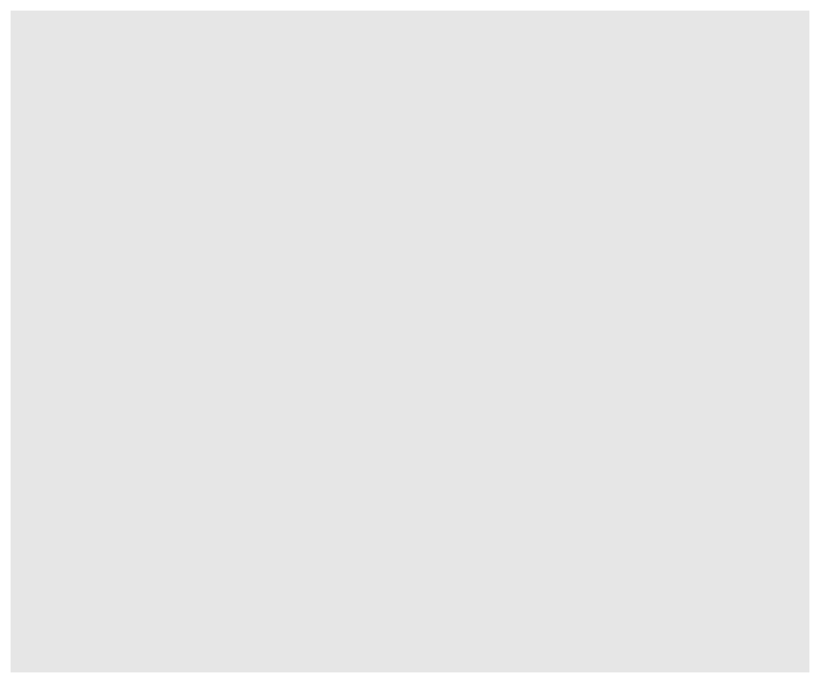

```r
ggplot(mpg)
```

## aes()

*Map columns in a datframe to ‘aesthetics’ in a ggplot*

This function lets us assign dataframe columsn to the different aesthtics in the plot including the x-axis, the y-axis, colour (for points and lines), fill (for bars, tiles and ribbons), alpha (transparency), shape and size. Components of a ggplot are added together with the `+` symbole…

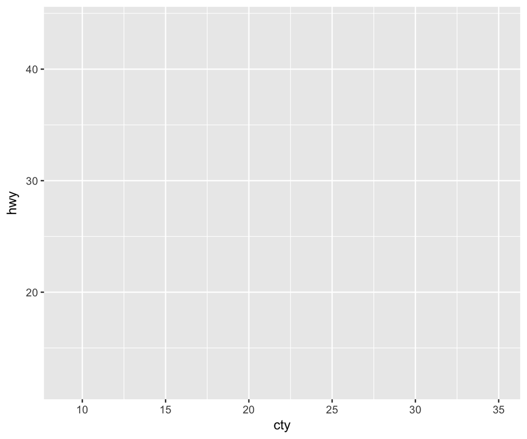

```r
ggplot(mpg) +
  aes(x = cty, y = hwy, colour = manufacturer)
```

## geom_point()

*add points to a ggplot*

Used to make sactterplots.

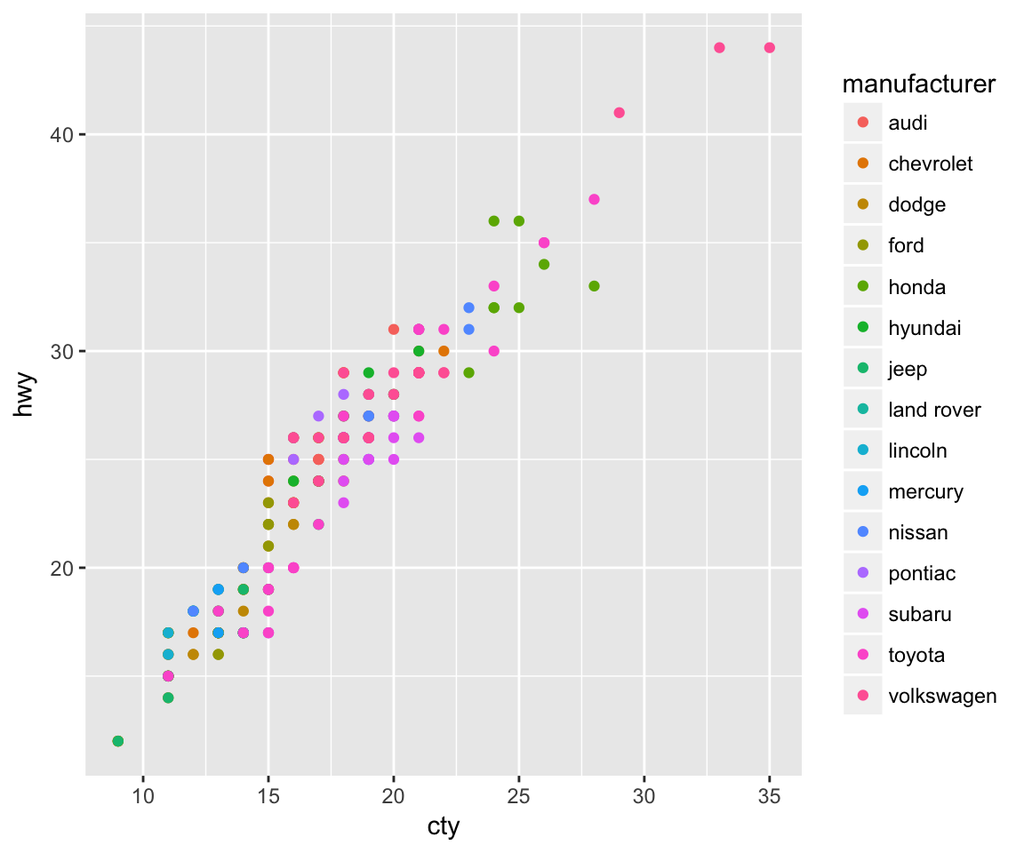

```r
ggplot(mpg) +
  aes(x = cty, y = hwy, colour = manufacturer) +
  geom_point()
```

## geom_line() & geom_path()

*add lines to a plot*

These functions add lines to a ggplot by joning up the points. `geom_path` does it in the order of the dataset and `geom_line` does it in the order along the x-axis. An example using the tidyverse built in economics dataset…

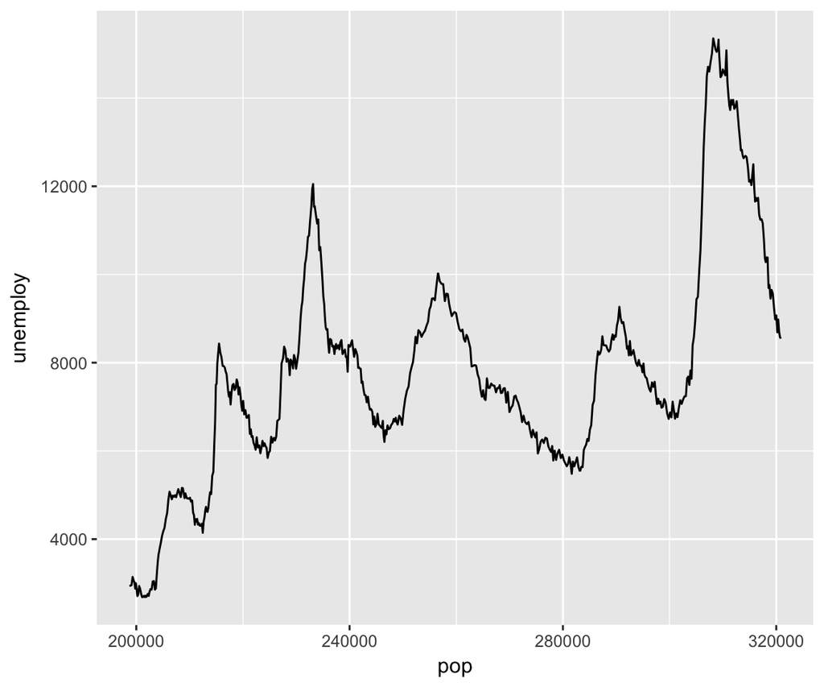

```r
ggplot(economics) +
  aes(x = pop, y = unemploy) +
  geom_line()
```

If you have several groups in a dataset you might need to add ‘groups’ as an aesthtic so you get a line per group. Using R’s `Orange’ dataset on growth of 5 orange trees….

```r
Orange %>%
  head()
```

```
Grouped Data: circumference ~ age | Tree
  Tree  age circumference
1    1  118            30
2    1  484            58
3    1  664            87
4    1 1004           115
5    1 1231           120
6    1 1372           142
```

If we plot this without groups our result looks odd..

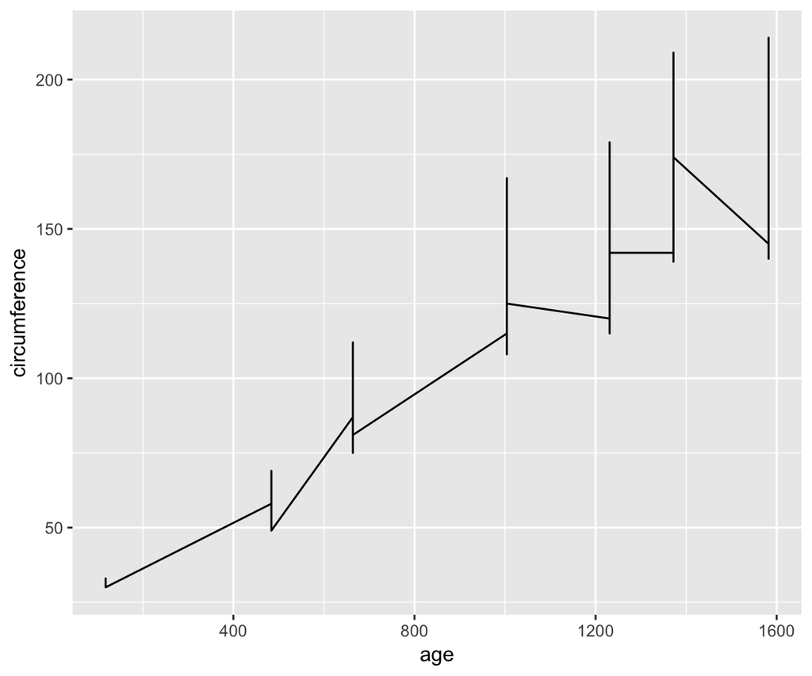

```r
ggplot(Orange) +
  aes(x = age, y = circumference) +
  geom_line()
```

Adding a ‘groups’ aesthetic sorts it out.

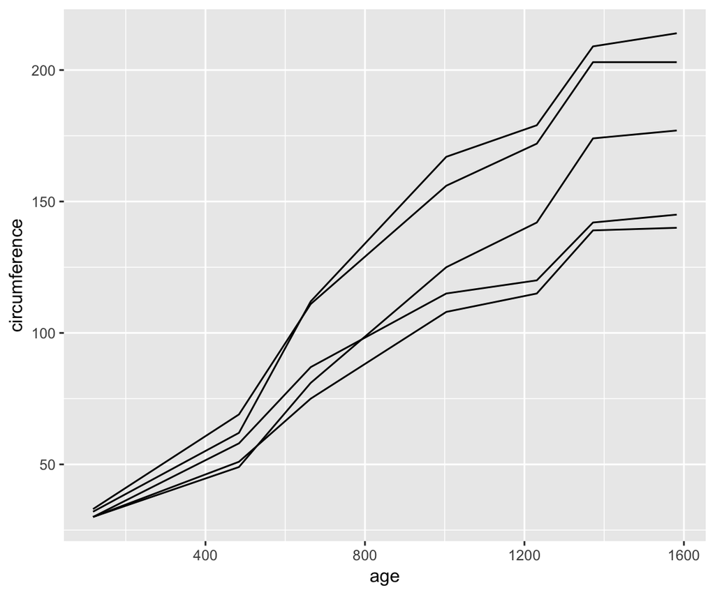

```r
ggplot(Orange) +
  aes(x = age, y = circumference, group = Tree) +
  geom_line()
```

## geom_bar()

*count up categorical values and plot as bars*

This function, by default, counts categorical variables (factors) and then draws a bar chart…

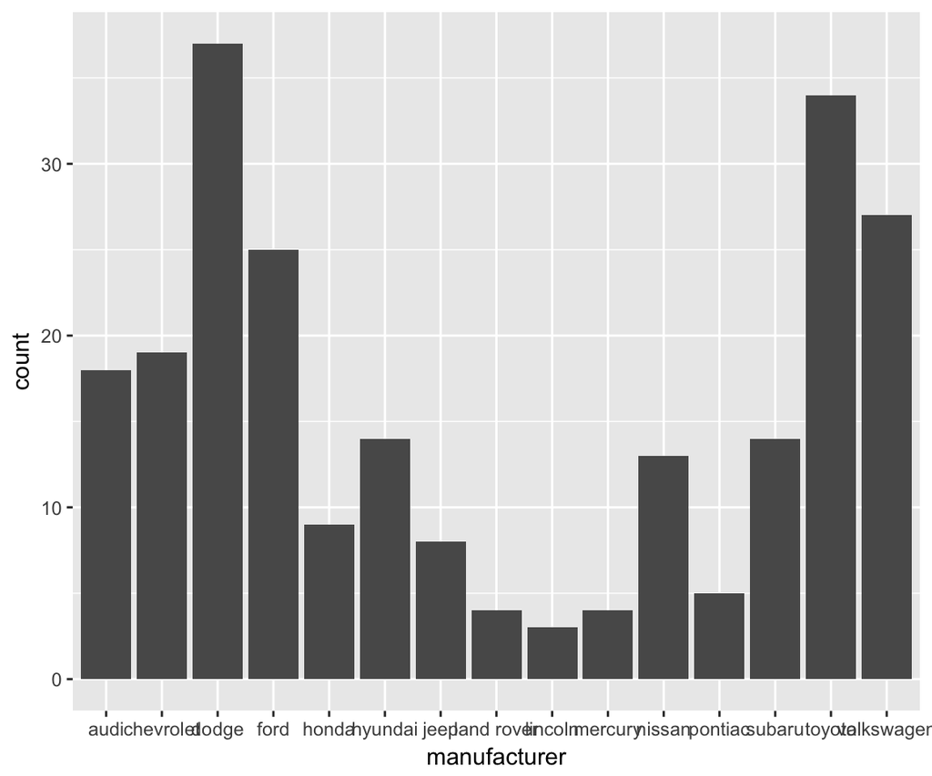

```r
ggplot(mpg) +
  aes(x = manufacturer) +
  geom_bar()
```

Bar charts can be easier to read if rotated using `coord_flip()`…

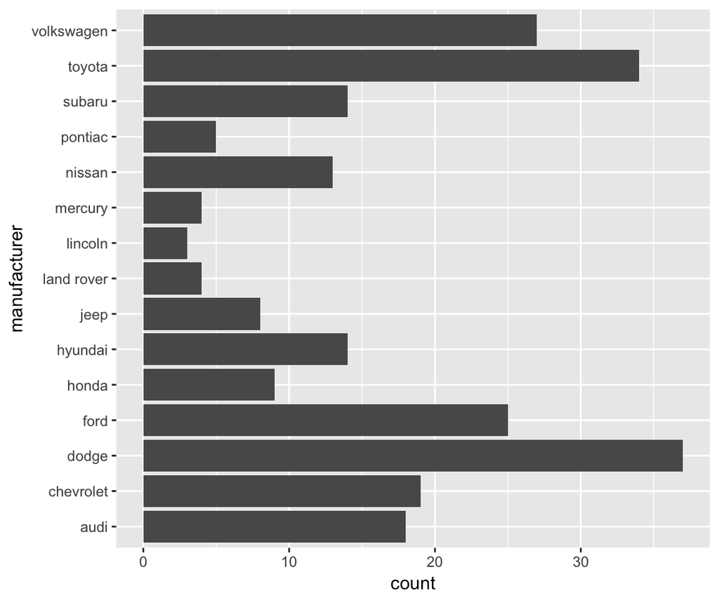

```r
ggplot(mpg) +
  aes(x = manufacturer) +
  geom_bar() +
  coord_flip()
```

## geom_histogram()

*count numeric datya into bins and plot a histogrm*

Given a numeric variable this function will generate bins (or you can give it bin numbers or widths) and will tally up the variable into the bins and then plot a histogram…

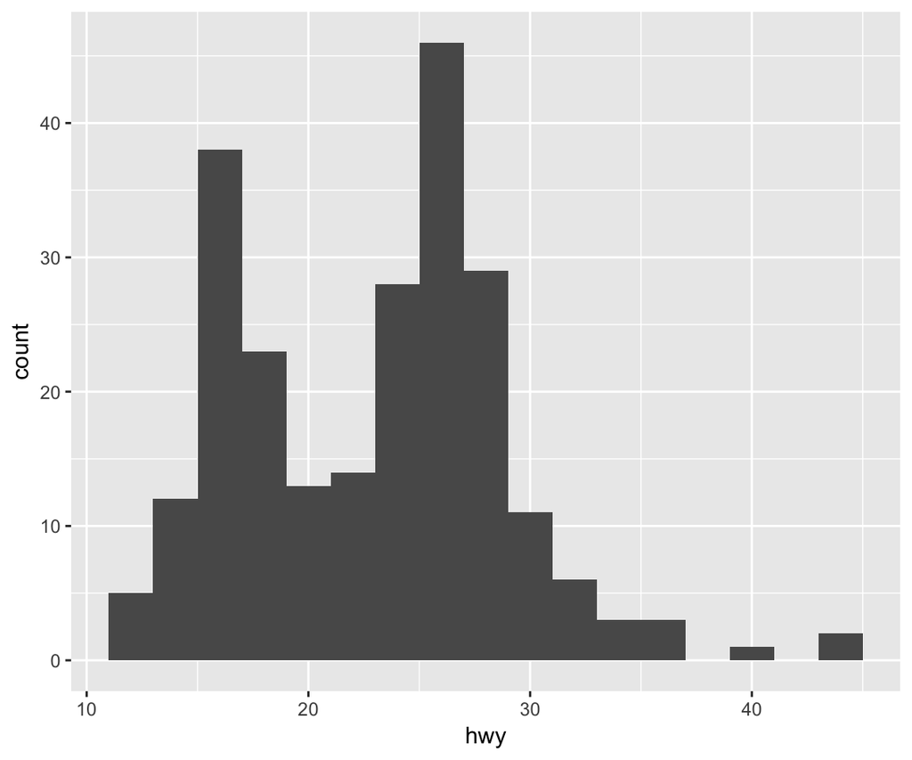

```r
ggplot(mpg) +
  aes(x = hwy) +
  geom_histogram(binwidth = 2)
```

## geom_boxplot() & geom_violin()

*show the distribution of numerical variables*

These functions will take a numerical variable and either produce a box plot (showing median, upper and lower quartiles, range and outliers) or a ‘violin-plot’ which is like a two-sided histogram. They are most useful when you want to show distribution of numerical variables in a number of categories. As the data we’ve used for the examples has long category names we’ve shown adding a `coord_flip()` onto each plot to flip them. It makes the category labels much easier to read!

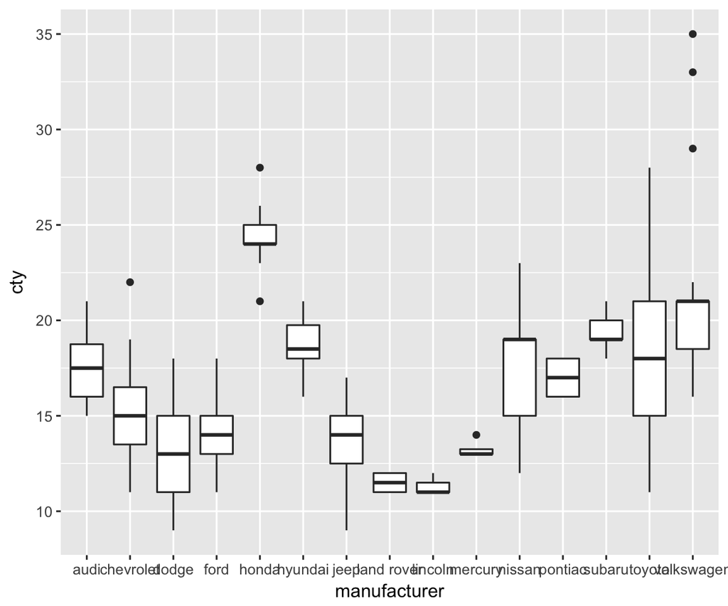

```r
ggplot(mpg) +
  aes(x = manufacturer, y = cty) +
  geom_boxplot()
```

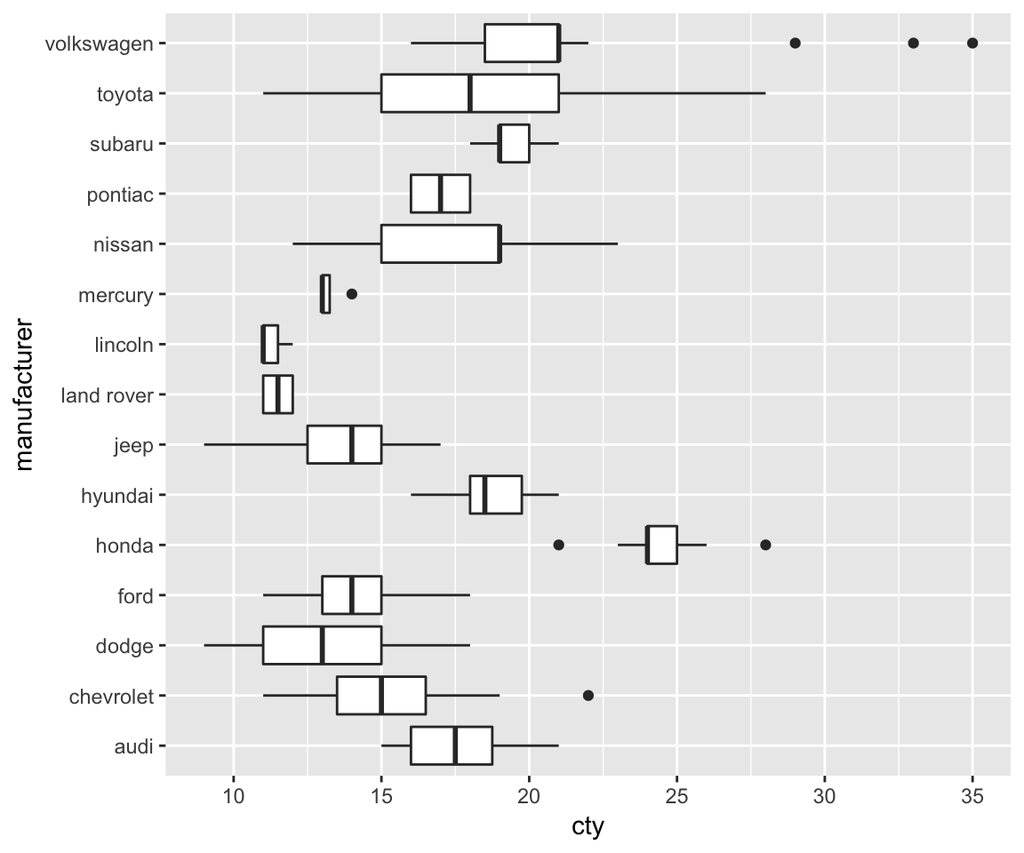

```r
ggplot(mpg) +
  aes(x = manufacturer, y = cty) +
  geom_boxplot() +
  coord_flip()
```

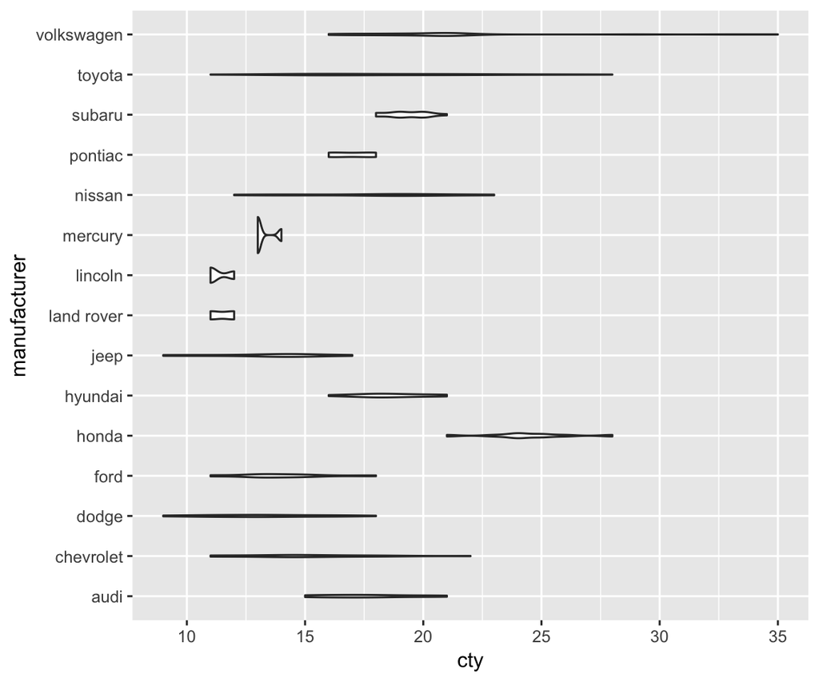

```r
ggplot(mpg) +
  aes(x = manufacturer, y = cty) +
  geom_violin() +
  coord_flip()
```

`geom_violin` has many options see [here](http://ggplot2.tidyverse.org/reference/geom_violin.html). Setting the scale argument to “width” makes all the ‘violins’ have the same width irrespective of the number of observations

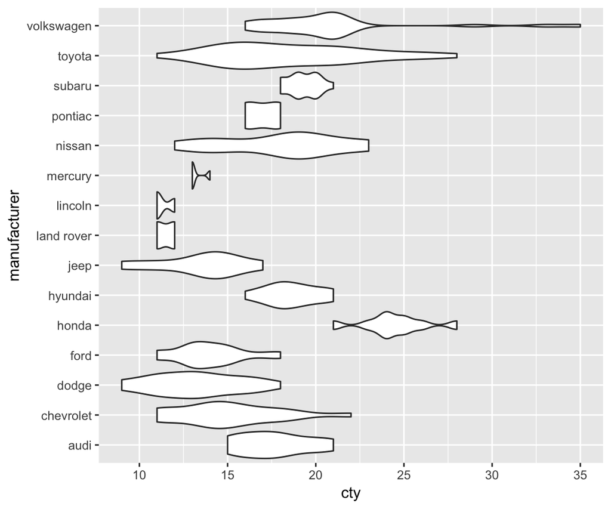

```r
ggplot(mpg) +
  aes(x = manufacturer, y = cty) +
  geom_violin(scale = "width") +
  coord_flip()
```

## labs()

*add titles and label text to a ggplot*

Allows you to add titles, subtitles, captions and label any aestheics you have used including x & y axes and colour / fill…

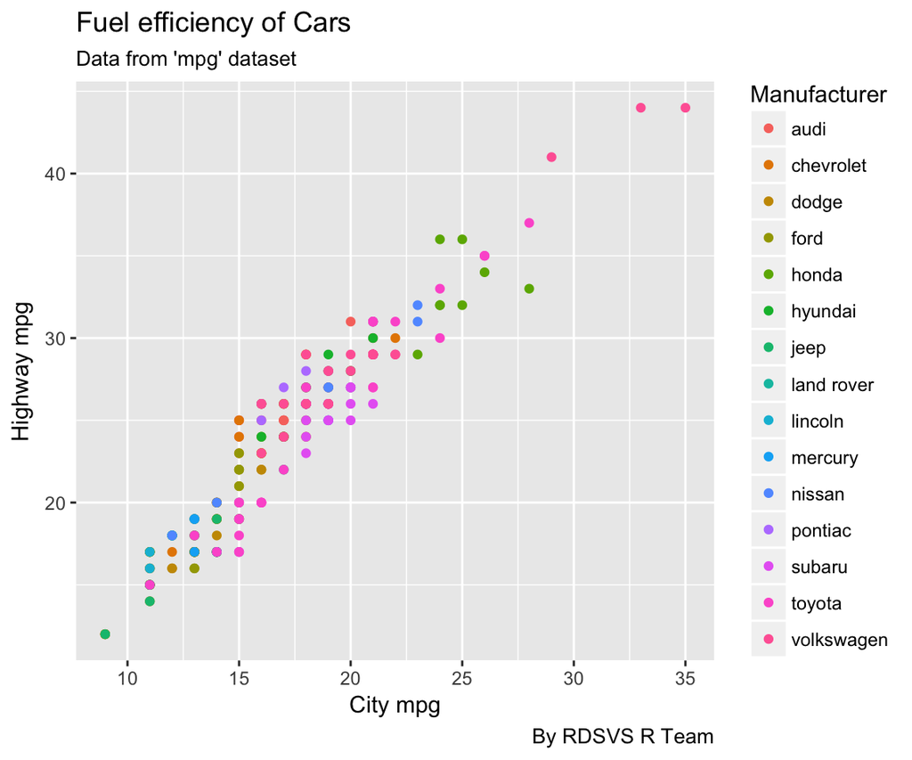

```r
ggplot(mpg) +
  aes(x = cty, y = hwy, colour = manufacturer) +
  geom_point() +
  labs(title = "Fuel efficiency of Cars",
       subtitle = "Data from 'mpg' dataset",
       caption = "By RDSVS R Team",
       x = "City mpg",
       y = "Highway mpg",
       colour = "Manufacturer")
```

## facet_wrap() & facet_grid()

_**divide a plot into sub-plots by one or more catergorical vaiables**

[figure not shown]

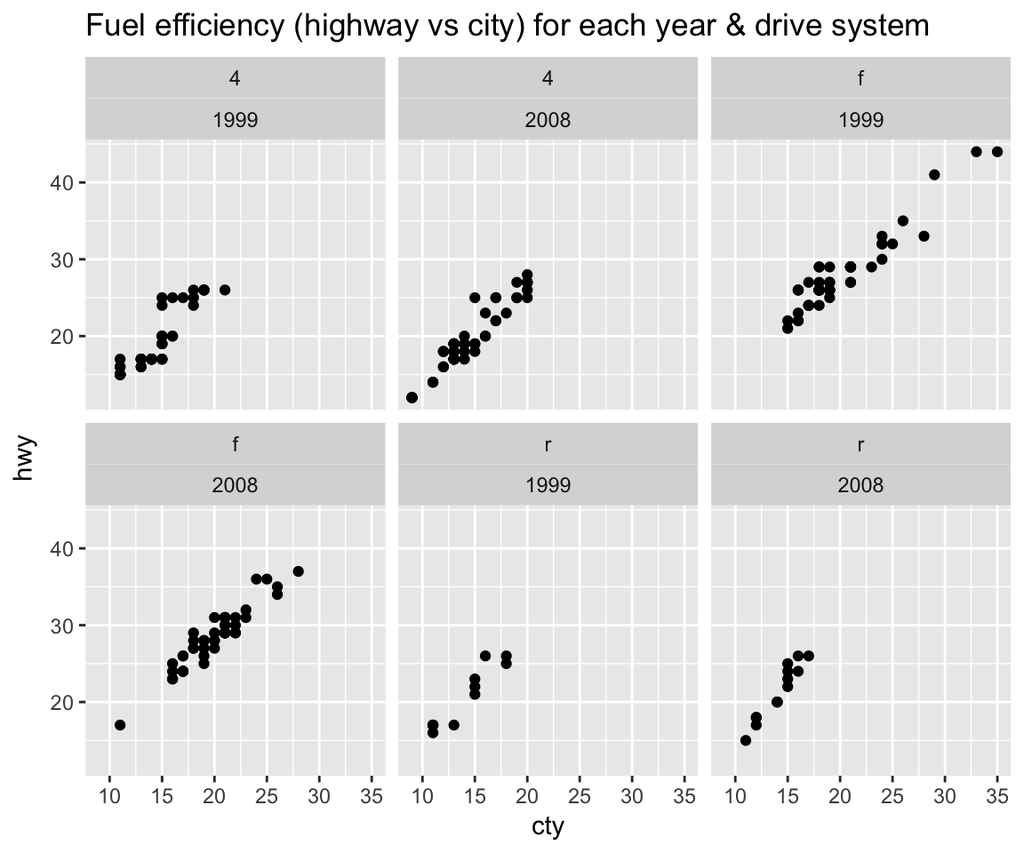

```r
ggplot(mpg) +
  aes(x = cty, y = hwy) +
  geom_point() +
  facet_wrap(drv ~ year) +
  labs(title = "Fuel efficiency (highway vs city) for each year & drive system")
```

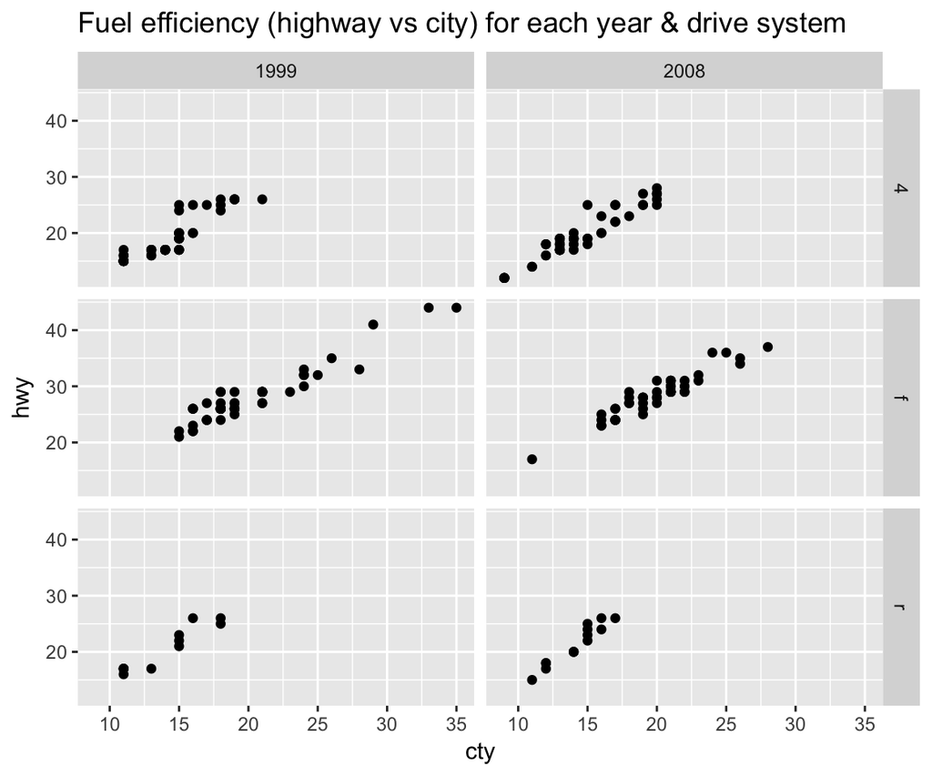

```r
ggplot(mpg) +
  aes(x = cty, y = hwy) +
  geom_point() +
  facet_grid(drv ~ year) +
  labs(title = "Fuel efficiency (highway vs city) for each year & drive system")
```

# Statistical tests

## t.test()

*run a Student’s T-Test on paired or unpaired data*

### unpaired data

To compare the means of two, indpendent groups - e.g. weights of two groups of animal seach group fed on a different diet.

First some data…

```r
weights_data <- tibble(diet = c("A", "A", "A", "A", "A", "B", "B", "B", "B", "B"),
                 weight = c(12, 15, 13, 16, 11, 34, 23, 15, 34, 43))
weights_data
```

```
# A tibble: 10 x 2
   diet  weight
   <chr>  <dbl>
 1 A        12.
 2 A        15.
 3 A        13.
 4 A        16.
 5 A        11.
 6 B        34.
 7 B        23.
 8 B        15.
 9 B        34.
10 B        43.
```

Then the T-Test

```r
t.test(weight ~ diet, data = weights_data)
```

```
    Welch Two Sample t-test

data:  weight by diet
t = -3.3066, df = 4.2894, p-value = 0.0268
alternative hypothesis: true difference in means is not equal to 0
95 percent confidence interval:
 -29.811901  -2.988099
sample estimates:
mean in group A mean in group B
           13.4            29.8
```

The output includes a p-value against the null hypothesis that the mean weights of the two populations you have samples from are the same; the T-statistic, the degress of freedom; the mean of each group and a confidence interval for the difference between the two means.